# Equations in two unknowns

### Three inconsistent equations

```r
A <- matrix(c(1,2,3, -1, 2, 1), 3, 2)
b <- c(2,1,6)
showEqn(A, b)
```

```
##      [,1]
## [1,] "1*x1 - 1*x2  =  2"
## [2,] "2*x1 + 2*x2  =  1"
## [3,] "3*x1 + 1*x2  =  6"
```

```r
c( R(A), R(cbind(A,b)) )          # show ranks
```

```
## [1] 2 3
```

```r
all.equal( R(A), R(cbind(A,b)) )  # consistent?
```

```
## [1] "Mean relative difference: 0.5"
```

An approximate solution is sometimes available using a generalized inverse.

```r
x <- MASS::ginv(A) %*% b
x
```

```
##      [,1]
## [1,]    2
## [2,]   -1
```

Plot the equations. You can see that each pair of equations has a solution, but all three do not have a common, consistent solution.

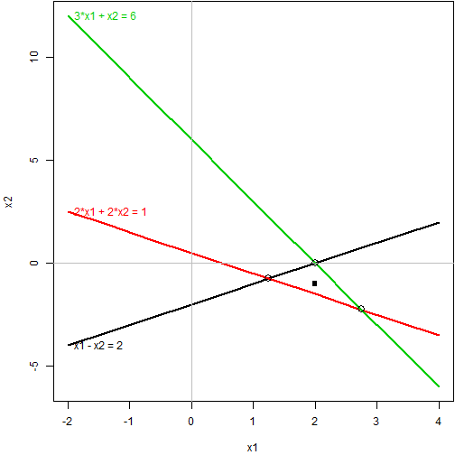

```r
plotEqn(A,b, xlim=c(-2, 4))
points(x[1], x[2], pch=15)
```

## Equations in three unknowns

Each equation in three unknowns corresponds to a plane in 3D space. The equations have a unique solution if all planes intersect in a point.

### Three consistent equations

```r
A <- matrix(c(2, 1, -1,
             -3, -1, 2,
             -2,  1, 2), 3, 3, byrow=TRUE)
colnames(A) <- paste0('x', 1:3)
b <- c(8, -11, -3)
showEqn(A, b)
```

```
##      [,1]
## [1,] "2*x1 + 1*x2 - 1*x3  =  8"
## [2,] "-3*x1 - 1*x2 + 2*x3  =  -11"
## [3,] "-2*x1 + 1*x2 + 2*x3  =  -3"
```

Are the equations consistent?

```r
c( R(A), R(cbind(A,b)) )          # show ranks
```

```
## [1] 3 3
```

```r
all.equal( R(A), R(cbind(A,b)) )  # consistent?
```

```
## [1] TRUE
```

Solve for \(\mathbf{x}\).

```r
solve(A, b)
```

```
## x1 x2 x3
##  2  3 -1
```

```r
solve(A) %*% b
```

```
##    [,1]
## x1    2
## x2    3
## x3   -1
```

```r
inv(A) %*% b
```

```
##      [,1]
## [1,]    2
## [2,]    3
## [3,]   -1
```

Another way to see the solution is to reduce \(\mathbf{A | b}\) to echelon form. The result is \(\mathbf{I | A^{-1}b}\), with the solution in the last column.

```r
echelon(A, b)
```

```
##      x1 x2 x3
## [1,]  1  0  0  2
## [2,]  0  1  0  3
## [3,]  0  0  1 -1
```

```r
echelon(A, b, verbose=TRUE, fractions=TRUE)
```

```
## row: 1
##      x1   x2   x3
## [1,]    1  1/3 -2/3 11/3
## [2,]    0  1/3  1/3  2/3
## [3,]    0  5/3  2/3 13/3
## row: 2
##      x1   x2   x3
## [1,]    1    0 -4/5 14/5
## [2,]    0    1  2/5 13/5
## [3,]    0    0  1/5 -1/5
## row: 3
##      x1 x2 x3
## [1,]  1  0  0  2
## [2,]  0  1  0  3
## [3,]  0  0  1 -1
```

```
##      x1 x2 x3
## [1,]  1  0  0  2
## [2,]  0  1  0  3
## [3,]  0  0  1 -1
```

Plot them. `plotEqn3d` uses `rgl` for 3D graphics. If you rotate the figure, you'll see an orientation where all three planes intersect at the solution point, \(\mathbf{x} = (2, 3, -1)\)

[interactive chart not shown]

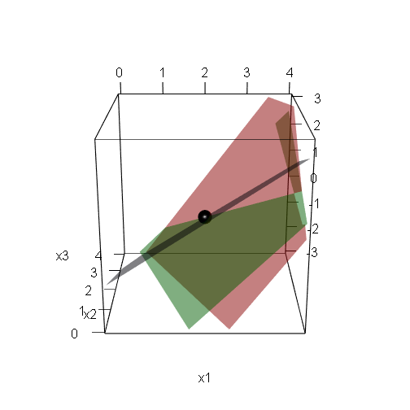

```r
plotEqn3d(A,b, xlim=c(0,4), ylim=c(0,4))
```

### Three inconsistent equations

```r
A <- matrix(c(1,  3, 1,
              1, -2, -2,
              2,  1, -1), 3, 3, byrow=TRUE)
colnames(A) <- paste0('x', 1:3)
b <- c(2, 3, 6)
showEqn(A, b)
```

```
##      [,1]
## [1,] "1*x1 + 3*x2 + 1*x3  =  2"
## [2,] "1*x1 - 2*x2 - 2*x3  =  3"
## [3,] "2*x1 + 1*x2 - 1*x3  =  6"
```

Are the equations consistent? No.

```r
c( R(A), R(cbind(A,b)) )          # show ranks
```

```
## [1] 2 3
```

```r
all.equal( R(A), R(cbind(A,b)) )  # consistent?
```

```
## [1] "Mean relative difference: 0.5"
```